# Lab 07 - ANÁLISIS DE REGRESIÓN MÚLTIPLE. ECUACIÓN DE REGRESIÓN MÚLTIPLE

Daniel Escriba Flores

# Contexto:

El Times-Observer es un periódico en la ciudad Metro. Al igual que muchos periódicos en la ciudad, el Times-Observer pasa por dificultades financieras. La gerente de circulación estudia otros periódicos en ciudades similares en Estados Unidos y Canadá, con interés particular en las variables que se relacionan con el número de suscriptores. Esta reúne la informacion muestral de 25 periódicos en ciudades similares empleando la siguiente notación:

- Suscriptores : Número de suscriptores (en miles)
- Población : Población metropolitana (en miles)
- Presupuesto : Presupuesto en publicidad del periódico (miles de dólares)
- Ingreso : Ingreso familiar medio en el área metropolitana (miles de dólares)

Deseando predecir el número de suscriptores con base a las otras variables, haga lo siguiente:

# Pregunta A: Datos, D-Dispersion e interpretacion

1. Lea la base de datos, elabore un diagrama de dispersión para cada variable independiente con la dependiente indicando e interpretando sus respectivos valores de coeficiente de correlación.

## Lectura de datos

```r
library(readxl)
library(pander)
library(equatiomatic)

data = read_excel("periódicos.xlsx", sheet="Hoja1")
data = data[-1]
data = as.data.frame(data)

# Usar pander para formatear la tabla
pander(data, caption = "Tabla de datos de suscripciones a periodicos de USA y Canada")
```

Tabla de datos de suscripciones a periodicos de USA y Canada

| Suscriptores | Población | Presupuesto | Ingreso |
| --- | --- | --- | --- |
| 37.95 | 588.9 | 13.2 | 35.1 |
| 37.66 | 585.3 | 13.2 | 34.7 |
| 37.55 | 566.3 | 19.8 | 34.8 |
| 38.78 | 642.9 | 17.6 | 35.1 |
| 37.67 | 624.2 | 17.6 | 34.6 |
| 38.23 | 603.9 | 15.4 | 34.8 |
| 36.9 | 571.9 | 11 | 34.7 |
| 38.28 | 584.3 | 28.6 | 35.3 |
| 38.95 | 605 | 28.6 | 35.1 |
| 39.27 | 676.3 | 17.6 | 35.6 |
| 38.3 | 587.4 | 17.6 | 34.9 |
| 38.84 | 576.4 | 22 | 35.4 |
| 38.14 | 570.8 | 17.6 | 35 |
| 38.39 | 586.5 | 15.4 | 35.5 |
| 37.29 | 544 | 11 | 34.9 |
| 39.15 | 611.1 | 24.2 | 35 |
| 38.29 | 643.3 | 17.6 | 35.3 |
| 38.09 | 635.6 | 19.8 | 34.8 |
| 37.83 | 598.9 | 15.4 | 35.1 |
| 39.37 | 657 | 22 | 35.3 |
| 37.81 | 595.2 | 15.4 | 35.1 |
| 37.42 | 520 | 19.8 | 35.1 |
| 38.83 | 629.6 | 22 | 35.3 |
| 38.33 | 680 | 24.2 | 34.7 |
| 40.24 | 651.2 | 33 | 35.8 |

### Medidas descriptivas

```r
summary(data)
```

```
##   Suscriptores     Población      Presupuesto       Ingreso
##  Min.   :36.90   Min.   :520.0   Min.   :11.00   Min.   :34.60
##  1st Qu.:37.81   1st Qu.:584.3   1st Qu.:15.40   1st Qu.:34.80
##  Median :38.28   Median :598.9   Median :17.60   Median :35.10
##  Mean   :38.30   Mean   :605.4   Mean   :19.18   Mean   :35.08
##  3rd Qu.:38.83   3rd Qu.:635.6   3rd Qu.:22.00   3rd Qu.:35.30
##  Max.   :40.24   Max.   :680.0   Max.   :33.00   Max.   :35.80
```

## Diagrama de dispersion

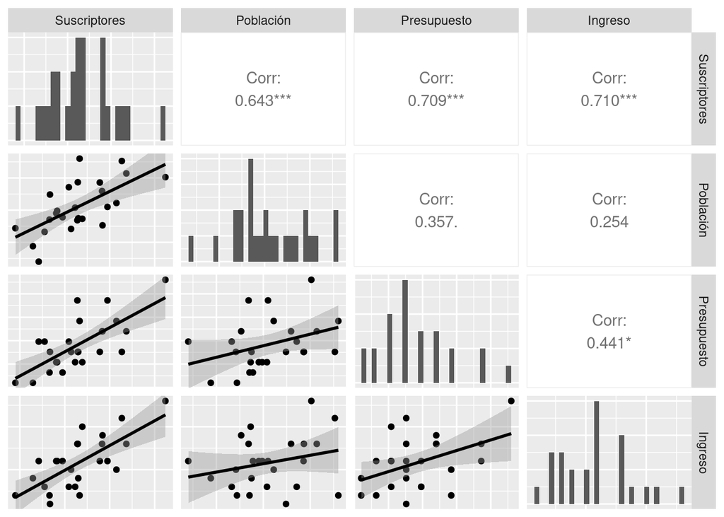

```r
#install.packages (”GGally”)

library(ggplot2)
library(GGally)

ggpairs(data,
        upper = list(continuous = "cor", na = "na"),
        columns=1:4,
        lower=list(continuous="smooth"),
        diag=list(continuous="barDiag"),
        axisLabels="none")
```

## Interpretacion de Correlaciones con la variable dependiente

- Población (0.643): Correlación positiva fuerte y significativa. A mayor población, mayor número de suscriptores.
- Presupuesto (0.709): Correlación positiva muy fuerte y significativa. Los presupuestos más altos están asociados con más suscriptores.
- Ingreso (0.710): La correlación más fuerte, positiva y significativa. Los mayores ingresos predicen claramente más suscriptores.

# Pregunta B: Regresion multiple y Ecuacion

2. Realice un análisis de regresión múltiple y escriba la ecuación de regresión múltiple.

## Regresion multiple

```r
modelo = lm(formula = Suscriptores ~ Población +
              Presupuesto +
              Ingreso,
            data= data)

summary(modelo)
```

```
##
## Call:
## lm(formula = Suscriptores ~ Población + Presupuesto + Ingreso,
##     data = data)
##
## Residuals:
##      Min       1Q   Median       3Q      Max
## -0.58362 -0.24463 -0.03801  0.25393  0.63750
##
## Coefficients:
##              Estimate Std. Error t value Pr(>|t|)
## (Intercept) -5.732813   8.427349  -0.680 0.503769
## Población    0.007537   0.001813   4.157 0.000446 ***
## Presupuesto  0.050883   0.014139   3.599 0.001689 **
## Ingreso      1.097381   0.245029   4.479 0.000207 ***
## ---
## Signif. codes:  0 '***' 0.001 '**' 0.01 '*' 0.05 '.' 0.1 ' ' 1
##
## Residual standard error: 0.3269 on 21 degrees of freedom
## Multiple R-squared:  0.8348, Adjusted R-squared:  0.8112
## F-statistic: 35.38 on 3 and 21 DF,  p-value: 2.144e-08
```

```r
modelo$coefficients
```

```
##  (Intercept)    Población  Presupuesto      Ingreso
## -5.732813186  0.007536582  0.050883394  1.097380777
```

### Interpretación del Modelo

Bondad de ajuste: R² = 0.8348 (83.48% de variabilidad explicada - excelente ajuste)

Variables significativas (todas con p < 0.01):

Población: cada aumento de 1 unidad aumenta 0.0075 suscriptores

Presupuesto: cada unidad adicional aporta 0.051 suscriptores

Ingreso: el predictor más fuerte (1.097 suscriptores por unidad)

## Ecuacion de regresion multiple

```
## Ecuación de regresión:
```

```
## Suscriptores = -5.732813 + 0.007536582 * Población + 0.05088339 * Presupuesto + 1.097381 * Ingreso
```

```r
# Versión básica
extract_eq(modelo)
```

$$\operatorname{Suscriptores} = \alpha +
\beta_{1}(\operatorname{Población}) +
\beta_{2}(\operatorname{Presupuesto}) +
\beta_{3}(\operatorname{Ingreso}) + \epsilon$$

```r
# Versión con valores de coeficientes
extract_eq(modelo, use_coefs = TRUE)
```

$$\operatorname{\widehat{Suscriptores}} = -5.73 +
0.01(\operatorname{Población}) + 0.05(\operatorname{Presupuesto}) +
1.1(\operatorname{Ingreso})$$

# Pregunta C: Pronostico

3. Realice un pronóstico cuando la población es de 600 000 habitantes, el presupuesto en publicidad del periódico es de 18 000 dólares y el ingreso familiar medio en el área metropolitana es de 36 000 dólares.

```r
predictores = data.frame(Población=600, Presupuesto=18, Ingreso=36)
pander(predictores, caption = "Tabla de datos predictores")
```

Tabla de datos predictores

| Población | Presupuesto | Ingreso |
| --- | --- | --- |
| 600 | 18 | 36 |

```r
costo_est = predict(object = modelo, newdata = predictores)
```

[output not shown]

# Conclusion

Para una ciudad con:

- 600,000 habitantes
- $18,000 de presupuesto publicitario
- $36,000 de ingreso familiar promedio

Se pronostican aproximadamente 39,210 suscriptores.

Estos resultados demuestran que las condiciones económicas y las inversiones en marketing son determinantes clave para el crecimiento de la base de suscriptores del periódico.